# 02_Analysis

**Foreword**

This notebook will be used to:

1. Do exploratory analysis on the dataset scraped in the notebook `01_Scraper.ipynb` such as:
   - compute statistics about the textual data of the 10-K files stored into the json files.
   - show the distribution of the companies in the dataset
   - show the evolution of the number of words and of the Gunning Fog Index (readability measure) of the 10-K files over the period of analysis.
2. Compute Guning Fog Index and lexical diversity
3. Compute and Assess a doct2vec model.
4. Compute similarity score (cos-sim) using the doc2vec model.
5. Apply finBert to the data to compute Management's tone
6. Run regression Analysis.

```python
from datetime import datetime
import pickle
import collections
import requests
from bs4 import BeautifulSoup
import pandas as pd
import os
from PIL import Image
from wordcloud import WordCloud
from itables import show
from IPython.display import display, HTML, Latex
import seaborn as sns
import numpy as np
import matplotlib.gridspec as gridspec
import matplotlib.pyplot as plt
import matplotlib as mpl
import matplotlib.ticker as ticker
from matplotlib.patches import Patch
import re
import json
from pathos.multiprocessing import ProcessPool
from functools import partial
from tqdm import tqdm
import warnings
import numpy as np
import nltk
from nltk import sent_tokenize
import string
from gensim.parsing.preprocessing import remove_stopwords
import shutil
# Disable all warnings
import torch
import gensim
from gensim.models.doc2vec import TaggedDocument, Doc2Vec
import ast
import pysentiment2 as ps
from sklearn.model_selection import train_test_split
from sklearn.utils.multiclass import unique_labels
from transformers import BertTokenizer, BertForSequenceClassification
from transformers import pipeline
from sklearn.metrics import confusion_matrix, f1_score, recall_score, accuracy_score, ConfusionMatrixDisplay, precision_score
from sklearn.metrics.pairwise import cosine_similarity
import seaborn as sns
from Functions import htmlLayout, PreProcessor, load_CSS
import pyphen
from nltk import pos_tag, sent_tokenize, wordpunct_tokenize, word_tokenize
import spacy
from sklearn.feature_extraction.text import TfidfVectorizer
from bs4 import BeautifulSoup
creator = htmlLayout()
if torch.backends.mps.is_available():
    mps_device = torch.device('mps')
    x = torch.ones(1, device = mps_device)
    print(x)
else:
    print('MPS device not found')
warnings.filterwarnings("ignore")

sns.set(style="whitegrid")
sns.set_palette("pastel")

with open('My_CSS_style.txt') as file:
    file_style = file.read()
directories = {'tables': '00_Data/00_Tables/',
               'corpus': {'raw': '00_Data/01_Corpus/00_Raw/',
                          'processed': {'headers': '00_Data/01_Corpus/01_Processed/00_Headers/',
                                        '10K': '00_Data/01_Corpus/01_Processed/01_10KFiles/',
                                        }
                         },
               'config': '00_Data/01_Corpus/',
               'models': '00_Data/02_Models/',
               'figures': '01_Figures/'
              }
corpus_dir = directories['corpus']['processed']['10K']
tables_dir = directories['tables']
model_dir = directories['models']
tables = directories['tables']
corpus_dir = directories['corpus']['processed']['10K']
fig_dir = directories['figures']
# plot options
sns.set_theme(rc={
    "axes.facecolor": (236/255, 236/255, 242/255, 0.3),
    "font.family": "Times New Roman",
    "grid.linewidth": 2.2,
    "axes.edgecolor": "black",
    "axes.linewidth": 0.5,
    "font.weight": 'normal'
})

color_mapping = {
    'Manufacturing': (0.6313725490196078, 0.788235294117647, 0.9568627450980393),
    'Finance, Insurance and Real Estate': (1.0, 0.7058823529411765, 0.5098039215686274),
    'Transportation, Communications, Electric Gas and Sanitary Service': (0.5529411764705883, 0.8980392156862745, 0.6313725490196078),
    'Services': (1.0, 0.6235294117647059, 0.6078431372549019),
    'Retail Trade': (0.8156862745098039, 0.7333333333333333, 1.0),
    'Mining': (0.8705882352941177, 0.7333333333333333, 0.6078431372549019),
    'Wholesale Trade': (0.9803921568627451, 0.6901960784313725, 0.8941176470588236),
    'Construction': (0.8117647058823529, 0.8117647058823529, 0.8117647058823529)

}

my_css_style = load_CSS(disp = True, export = True)
```

```
tensor([1.], device='mps:0')
```

# 1. Structual Analysis and Descriptive Statistics

## 1.1. Textual Analysis

### 1.1.1. Structural Analysis

We created a class named `PreProcessor()` based on Bengfort, Bilbro and Ojeda (2018: Chapter 3) (see file `Functions.py`) that will allows us to have a clear structural picture of the textual content of the 10-K files. This class contains severals functions, being one of them the `describe()` function that, among other things, counts the number of words, the number unique words (tokens), the number of sentences, the number of "complex words", the lexical diversity and calculates the Gunning Fog Index (GFI). These metrics are separated by items when applicable and also computed at a (whole) document level, i.e. considering the whole 10-K.

Given a document (10-K files) $d$ and its section (or item) $i$, the Gunning Fog Index for a specific section is computed as:

\begin{align} GFI_{i,d}&=&\left[\frac{\text{total number of words}_{i,d}}{\text{total number of sentences}_{i,d}}+\frac{\text{total number of complex words}_{i,d}}{\text{total number of words}_{i,d}}*100\right]*0.4 \tag {1.1} \label{eq:1.1} \end{align}

At a document level, the index $i$ is dropped. Complex word is defined as any word with more than two syllables.

The lexical diversity (lexdiv) is defined as the ratio of the total number of unique words (tokens) divided by the number total number words. Say:

\begin{align} lexdiv_{i,d} = \frac{\text{total number of unique words (tokens)}_{i,d}}{\text{total number of words}_{i,d}} \tag {1.2} \label{eq:1.2} \end{align}

Our starting point are the 10-K json files stored in json format. The `start_description()` function of the mentioned class opens all the files in the directory, which are stored in a dictionary manner (json). Each key is an section (more specifically an item) of the 10-K file. So the function iterate over the items, break them into sentences, remove when specified bullet points, breaks, digits and punctuations and apply the mathematical operations. The reason for the removal of the punctuations, digits and similar tokens is that they are not condiered by the computation of the Gunning Fog Index. In order to count the syllables of the words, we use the `pyphen`-module.

Notice that at a first moment, the function is applied to every 10-K file in the directory. Independently whether a company will be kept in the data-set or not.

```python
preprocessor = PreProcessor(
    directory = corpus_dir,
    item = 'all',
    remove_bullets = True,
    remove_breaks = True,
    remove_digits = True,
    remove_punct = True
)
df_text_structure_raw = preprocessor.start_description()
# drop any duplicated value
df_text_structure_raw.drop_duplicates(inplace = True)
```

We will now save the dataset just created and read it in again.

```python
file_name = "Analysis_Ch1_CorpusStructuralDescriptionRaw.csv"
#df_text_structure_raw.to_csv(tables_dir + file_name, index = False)
```

```python
#read the data set again
df_text_structure_raw = pd.read_csv(tables_dir + file_name, index_col = None)
```

```python
creator.tabDesc(
    title = "Structual Analysis I (All Files in Directory)",
    caption = "Table contains a structural description about the 10-K reports in the directory. The table shows statistics for all the files that could be scraped from the SEC. The first column displays the file name and the second column displays the item in the 10-K for which the metrics to the right were computed.<br> filename is the name of the json-file containing the report in text format; item refers to the section of the report, when item equals 'Overall', all sections of the report are considered in the computation; items_count counts the number of items in a report and is only defined at a document level (when item has value equal to 'Overall'); sentences, words, vocab and complex counts the total number of sentences, words, unique words, and complex words in an item or in a document; lexdiv represents the lexical diversity in the text of an item or document, and is defined as the ratio between the total number of unique words and total number of words, being a number between zero and one; spit computes the number of sentences per item and is also only defined at a document level; GFI is the Gunning Fog Index, the measured used to represent the readability of the text, the higher the GFI , the more difficult a text is considered to be read.",
    cap_style = 'font-size:13px; text-align: justify;',
    type = 'Tab',
    type_num = '1.1.',
    disp = True,
)
show(df_text_structure_raw)
```

Structual Analysis I (All Files in Directory)

Tab 1.1.: Table contains a structural description about the 10-K reports in the directory. The table shows statistics for all the files that could be scraped from the SEC. The first column displays the file name and the second column displays the item in the 10-K for which the metrics to the right were computed.  
filename is the name of the json-file containing the report in text format; item refers to the section of the report, when item equals 'Overall', all sections of the report are considered in the computation; items_count counts the number of items in a report and is only defined at a document level (when item has value equal to 'Overall'); sentences, words, vocab and complex counts the total number of sentences, words, unique words, and complex words in an item or in a document; lexdiv represents the lexical diversity in the text of an item or document, and is defined as the ratio between the total number of unique words and total number of words, being a number between zero and one; spit computes the number of sentences per item and is also only defined at a document level; GFI is the Gunning Fog Index, the measured used to represent the readability of the text, the higher the GFI , the more difficult a text is considered to be read.

| filename | item | items_counts | sents | words | vocab | lexdiv | spit | complex | GFI |
| --- | --- | --- | --- | --- | --- | --- | --- | --- | --- |
| Loading... (need [help](https://mwouts.github.io/itables/troubleshooting.html)?) |  |  |  |  |  |  |  |  |  |

The focus of our analysis does not lies on the whole 10-K file, but on the textual content of the **Management's Discussion and Analysis of Financial Position and Results of Operations (MD&A)**. Given that some companies write this section by referencing to another section, we will only keep files that have at least 3 sentences in their MD&A. When this is not the case, the whole company will be excluded from the data set in order to keep the balance of the panel.

Further, recall that we dropped other companaies from our data set at the end of Section 6 in the notebook `01_Scraper.ipynb`. Hence, we will keep only those companies in the analysis.

```python
# create an extra column in the dataframe df_text_structure to contain the ciks of the companies
df_text_structure_raw['cik'] = df_text_structure_raw['filename'].apply(lambda x: x[:10])
# get the total number of companies before the operation
unique_ciks_before_operation = df_text_structure_raw['cik'].nunique()
# load the dataset containing the betas (it has a cik and ticker column)
df_betas = pd.read_csv(tables_dir + 'Scraper_Ch5_BetasFinal_Weekly.csv', dtype = {'cik':str})
# now keep only companies that are common to both datasets
df_text_structure = df_text_structure_raw[df_text_structure_raw['cik'].isin(df_betas['cik'].tolist())].copy(deep = True)
```

```python
# get only item 7
df_item7 = df_text_structure[df_text_structure['item'] == 'item_7'].copy(deep = True)
# now get only df_items with more than two sentences
df_item7 = df_item7[df_item7['sents'] > 2]
```

```python
# count the number of times a given cik appear in the dataset and check which cik appears 8 time (the code will return a boolean)
df_counts = df_item7['cik'].value_counts() == 8
# get the ciks for which the condition was met.
keep_ciks = set([value for value, condition in zip(df_counts.index.tolist(), df_counts.tolist()) if condition])
```

```python
# now keep only the rows with cik that are contained in the list keep_ciks
df_text_structure = df_text_structure[df_text_structure['cik'].isin(keep_ciks)]
# print out the number of unique companies left in the dataset
unique_ciks_after_operation = df_text_structure['cik'].nunique()
print('There are {} of initial {} left in the dataset. For these companies we have 8 10-K files (for the years spanning 2016 to 2023) whose item 7 (MD&A) has at least 3 sentences.'.format(unique_ciks_after_operation, unique_ciks_before_operation))
# drop the auxiliary column with the cik
#df_text_structure.drop(columns = ['cik'], inplace = True)
```

```
There are 394 of initial 418 left in the dataset. For these companies we have 8 10-K files (for the years spanning 2016 to 2023) whose item 7 (MD&A) has at least 3 sentences.
```

```python
total_doc = df_text_structure[df_text_structure['item'] == 'Overall']['filename'].nunique()
print('In total we have {} documents'.format(total_doc))
```

```
In total we have 3152 documents
```

We now save this data set and read it in again.

```python
file_name = 'Analysis_Ch1_CorpusStructuralDescriptionCleaned.csv'
#df_text_structure.to_csv(tables_dir + file_name, index = False)
```

```python
# read the dataset
df_text_structure = pd.read_csv(tables_dir + file_name, index_col = None)
creator.tabDesc(
    title = 'Structural Analysis II',
    caption = "Table contains a structural description about the 10-K reports in the directory. The table shows statistics for all the files of those companies for which exactly 8 10-K reports were successfully obtained and whose MD&A-section has at least 3 sentences. The first column displays the file name and the second column displays the item in the 10-K for which the metrics to the right were computed.<br> filename is the name of the json-file containing the report in text format; item refers to the section of the report, when item equals 'Overall', all sections of the report are considered in the computation; items_count counts the number of items in a report and is only defined at a document level (when item has value equal to 'Overall'); sentences, words, vocab and complex counts the total number of sentences, words, unique words, and complex words in an item or in a document; lexdiv represents the lexical diversity in the text of an item or document, and is defined as the ratio between the total number of unique words and total number of words, being a number between zero and one; spit computes the number of sentences per item and is also only defined at a document level; GFI is the Gunning Fog Index, the measured used to represent the readability of the text, the higher the GFI , the more difficult a text is considered to be read.",
    cap_style = 'font-size:13px; text-align:justify;',
    type = 'Tab',
    type_num = '1.2.',
    disp = True
)
show(df_text_structure)
```

Structural Analysis II

Tab 1.2.: Table contains a structural description about the 10-K reports in the directory. The table shows statistics for all the files of those companies for which exactly 8 10-K reports were successfully obtained and whose MD&A-section has at least 3 sentences. The first column displays the file name and the second column displays the item in the 10-K for which the metrics to the right were computed.  
filename is the name of the json-file containing the report in text format; item refers to the section of the report, when item equals 'Overall', all sections of the report are considered in the computation; items_count counts the number of items in a report and is only defined at a document level (when item has value equal to 'Overall'); sentences, words, vocab and complex counts the total number of sentences, words, unique words, and complex words in an item or in a document; lexdiv represents the lexical diversity in the text of an item or document, and is defined as the ratio between the total number of unique words and total number of words, being a number between zero and one; spit computes the number of sentences per item and is also only defined at a document level; GFI is the Gunning Fog Index, the measured used to represent the readability of the text, the higher the GFI , the more difficult a text is considered to be read.

| filename | item | items_counts | sents | words | vocab | lexdiv | spit | complex | GFI | cik |
| --- | --- | --- | --- | --- | --- | --- | --- | --- | --- | --- |
| Loading... (need [help](https://mwouts.github.io/itables/troubleshooting.html)?) |  |  |  |  |  |  |  |  |  |  |

The values displayed by the output above are:

- filename: the file used to compute the statistics
- item: gives information whose items the statistics belong to. For the statistics related to the whole document, the item has value 'Overall'.
- intems_count: the number of items in the document. Value is only defined for statistics related to the whole document, say, when item = 'Overall'
- sents: the number of sentences in the item or document.
- words: the number of words (tokens) returned by the `wordpunct_tokenizer` from `NLTK` module. It should be noted that punctuation, special characters and digits were not considered as words.
- vocabulary: the number of unique tokens in the item or document.
- lexdiv: a metric for text richness. Defined to be the ration between the total number of unique words (tokens) and the total number of words, being a value in interval $\left[0;1\right]$. The closer to 1, the more richer the text.
- complex: the total number of complex words as defined by the GF-index.
- GF: Gunning Fox index, used as a measure of readability.

### 1.1.2. Statistics

In this section we will divide the data set created at the end of Section 1.1.1., i.e. `02_Analysis_Ch1_CorpusStructuralDescriptionCleaned.csv` into two further data-sets, one containing the structural metrics for the a given 10-K report as a whole (where items = "Overall") and another containing only the MD&A sections; we then compute some descriptive statistics to understand the distribution of the metrics, and specially how the total number of words and the Gunning Fog Index evolved over time.

As in a latter stage we will be visualizing the data divided by industries, we will use the last dataset (called `Scraper_Ch6_AggregatedFinal.csv`) created in hte `01_Scraper.ipynb` notebook to obain the industries of the companies. The dataset has a column with the cik that can be used in conjunctution with the cik stored in the file name in the dataset `df_text_structure` that can be used to join them both. We also create a column with the filing year of the reports in order to be able to study the time-evolution of the metrics. The year of submission can be inferred by using the accession number of a file (the second part in the filename column); e.g. the file name *0000798287_accn0001437749-23-006150.json* has the pattern *cik_accn_10digits-year-6digits*, where year here is the year of submission. Hence, we can and will get the dates from the file-name.

```python
# create a dictionary to hold the dataframes with the descriptions:
stats_dict = {}
```

```python
file_name = 'Analysis_Ch1_CorpusStructuralDescriptionCleaned.csv'
# read the dataset
df_text_structure = pd.read_csv(tables_dir + file_name, index_col = None)
df_aggregated = pd.read_csv(tables_dir + 'Scraper_Ch6_AggregatedFinal.csv', dtype = {'cik': str}, index_col = None)
# create a column in df_text_structure to store the cik
df_text_structure['cik'] = df_text_structure['filename'].str.split('_').str.get(0)
# now append the column with the industries of df_aggregated to df_text_structure
df_text_structure = pd.merge(df_text_structure, df_aggregated[['Industry', 'cik']], on = 'cik', how = 'inner')
# get filing date
df_text_structure['FilingYear'] = ('20' + df_text_structure['filename'].str.split('-').str.get(1)).astype(int)
df_text_structure.drop_duplicates(inplace = True)
```

```python
df_item7 = df_text_structure[df_text_structure['item'] == 'item_7'].copy(deep = True)
df_overall = df_text_structure[df_text_structure['item'] == 'Overall'].copy(deep = True)
for column in df_overall.columns.tolist():
    try:
        # make sure that the numerical columns are in float instead of string format
        df_overall[column] = df_overall[column].to_numpy(float)
        df_item7[column] = df_item7[column].to_numpy(float)
    except:
        pass
```

In the next section, we will start with the description of the 10-K as a whole and in the subsequent section, we turn our attention to the MD&A-sections.

#### 10-K description

Instead of describing all variables in the data set, we will be focusing on the total number of sentences, words, complex words, Gunning Fog Index and the lexical diversity.

```python
# start with the overall description
df_desc_overall = df_overall.copy(deep = True)
# group the dataset by year
df_desc_overall_grouped = df_desc_overall.groupby('FilingYear')

# instead of describing all variables of the dataset, let do a description with only the variables that is of interest (words, sents, complex, GFI, lexdiv)
var_desc = ['words', 'sents', 'complex', 'GFI', 'lexdiv']
df_desc_overall_grouped = df_desc_overall_grouped[var_desc].describe()
columns = [col for col in df_desc_overall_grouped.keys() if 'count' not in col]

# save the dataframe to the dictionary we created to hold teh descriptions-df
stats_dict['stats_peryear_10K'] = df_desc_overall_grouped
creator.tabDesc(
    title = 'Descriptive Statistics (Textual Features - 10K Files)',
    caption = 'Table describes the mean, the standard deviation, the maximum and minimum values as well as the quartiles of total number of words, sentences, complex words, lexical diversity and the Gunning Fog Index aggregated per year for all the 394 files at a document level (i.e. considering the whole 10-K) in the dataset.',
    cap_style = 'font-size:13px; text-align: justify;',
    type = 'Tab.',
    type_num = '1.3.',
    disp = True
)
show(df_desc_overall_grouped[columns])
```

Descriptive Statistics (Textual Features - 10K Files)

| FilingYear | words mean | words std | words min | words 25% | words 50% | words 75% | words max | sents mean | sents std | sents min | sents 25% | sents 50% | sents 75% | sents max | complex mean | complex std | complex min | complex 25% | complex 50% | complex 75% | complex max | GFI mean | GFI std | GFI min | GFI 25% | GFI 50% | GFI 75% | GFI max | lexdiv mean | … |
| --- | --- | --- | --- | --- | --- | --- | --- | --- | --- | --- | --- | --- | --- | --- | --- | --- | --- | --- | --- | --- | --- | --- | --- | --- | --- | --- | --- | --- | --- | --- |
| Loading... (need [help](https://mwouts.github.io/itables/troubleshooting.html)?) |  |  |  |  |  |  |  |  |  |  |  |  |  |  |  |  |  |  |  |  |  |  |  |  |  |  |  |  |  | … |

we now compute the mean for the variables *words*, *sents*, *complex*, *GFI*, and *lexdiv* considering all the years, as well as the total number for the discrete variables.

```python
# get the mean of the means
mean_cols = []
for col in df_desc_overall_grouped.columns:
    if 'mean' in col:
        mean_cols.append(col)
# create a dataframe with the means
df_means_overall = pd.DataFrame({key[0]: value for key, value in df_desc_overall_grouped[mean_cols].mean().round(2).items()}, index = ['Mean'])
# get the keys of the means df
# calculate the total number
mean_cols = mean_cols[:-2]
# hence, in order to obtain an integer, we will round the results again
df_total_overall = pd.DataFrame(data = [[number for number in (df_desc_overall_grouped[mean_cols].mean() * 394 * 8)]],
                                columns = ['words', 'sents', 'complex'], index = ['Total'])
# add the variables GFI and lexdiv to the total_df
df_total_overall['GFI'] = '--'
df_total_overall['lexdiv'] = '--'

# now join both daframes
df_desc_overall_allyears = pd.concat([df_means_overall, df_total_overall]).T.rename_axis('Variables', axis=0)
```

```python
# save the dataframe to the dictionary we created to hold teh descriptions-df
stats_dict['stats_mean_total_10K'] = df_desc_overall_allyears

creator.tabDesc(
    title = 'Metrics: Mean and Total Considering all the Years (10-K Files)',
    caption = 'Table displays in its first column the average of the metrics shown in the index (number of words, sentences, complex words and Gunning Fox Index). The second column column contains the total number of the aforementioned metrics. In order to calculate the mean and total, the 10-K files for all years (2016-2023) were considered.',
    disp = True,
    type = 'Tab.',
    type_num = '1.4.',
    cap_style = 'font-size:13px; text-align: justify;'
)
show(df_desc_overall_allyears)
```

Metrics: Mean and Total Considering all the Years (10-K Files)

Tab. 1.4.: *Table displays in its first column the average of the metrics shown in the index (number of words, sentences, complex words and Gunning Fox Index). The second column column contains the total number of the aforementioned metrics. In order to calculate the mean and total, the 10-K files for all years (2016-2023) were considered.*

| Variables | Mean | Total |
| --- | --- | --- |
| Loading... (need [help](https://mwouts.github.io/itables/troubleshooting.html)?) |  |  |

The output above tells us that, over all the years the average 10-K report has 52,249 words being 11910 of them complex, an average of 1813 sentences, a GFI of 20.61 and a lexical richness (diversity) of 0.08 points.

In total our corpus has 164,646,461 words, being 37,537,755 (around 22.80%) of them complex, and a total number of 5,711,738 sentences.

We will now do the same process considering only the MD&A-section of the 10-Ks. In the next section

#### MD&A description

Again we begin by creating extras data sets to hold the statistics for the MD&A sections.

```python
# start with the overall description

df_desc_item7 = df_item7.copy(deep = True)
# group the dataset by year
df_desc_item7_grouped = df_desc_item7.groupby('FilingYear')

# instead of describing all variables of the dataset, let do a description with only the variables that is of interest (words, sents, complex, GFI, lexdiv)
var_desc = ['words', 'sents', 'complex', 'GFI', 'lexdiv']
df_desc_item7_grouped = df_desc_item7_grouped[var_desc].describe()
columns = [col for col in df_desc_item7_grouped.keys() if 'count' not in col]
```

```python
# save the dataframe to the dictionary we created to hold teh descriptions-df
stats_dict['stats_peryear_MD&A'] = df_desc_item7_grouped
creator.tabDesc(
    title = 'Descriptive Statistics (Textual Features - MD&A Sections)',
    caption = 'Table describes the mean, the standard deviation, the maximum and minimum values as well as the quartiles of total number of words, sentences, complex words, lexical diversity and the Gunning Fog Index aggregated per year for the Management’s Discussion and Analysis of Financial Condition and Results of Operations (item 7) found in the 10-Ks of the 394 companies in the dataset.',
    cap_style = 'font-size:13px; text-align: justify;',
    type = 'Tab.',
    type_num = '1.5.',
    disp = True
)
show(df_desc_item7_grouped[columns])
```

Descriptive Statistics (Textual Features - MD&A Sections)

Tab. 1.5.: *Table describes the mean, the standard deviation, the maximum and minimum values as well as the quartiles of total number of words, sentences, complex words, lexical diversity and the Gunning Fog Index aggregated per year for the Management’s Discussion and Analysis of Financial Condition and Results of Operations (item 7) found in the 10-Ks of the 394 companies in the dataset.*

| FilingYear | words mean | words std | words min | words 25% | words 50% | words 75% | words max | sents mean | sents std | sents min | sents 25% | sents 50% | sents 75% | sents max | complex mean | complex std | complex min | complex 25% | complex 50% | complex 75% | complex max | GFI mean | GFI std | GFI min | GFI 25% | GFI 50% | GFI 75% | GFI max | lexdiv mean | … |
| --- | --- | --- | --- | --- | --- | --- | --- | --- | --- | --- | --- | --- | --- | --- | --- | --- | --- | --- | --- | --- | --- | --- | --- | --- | --- | --- | --- | --- | --- | --- |
| Loading... (need [help](https://mwouts.github.io/itables/troubleshooting.html)?) |  |  |  |  |  |  |  |  |  |  |  |  |  |  |  |  |  |  |  |  |  |  |  |  |  |  |  |  |  | … |

```python
# get the mean of the means
mean_cols = []
for col in df_desc_item7_grouped.columns:
    if 'mean' in col:
        mean_cols.append(col)
# create a dataframe with the means
df_means_item7 = pd.DataFrame({key[0]: value for key, value in df_desc_item7_grouped[mean_cols].mean().round(2).items()}, index = ['Mean'])
# get the keys of the means df
# calculate the total number
mean_cols = mean_cols[:-2]
# hence, in order to obtain an integer, we will round the results again
df_total_item7 = pd.DataFrame(data = [[number for number in (df_desc_item7_grouped[mean_cols].mean() * 394 * 8)]],
                                columns = ['words', 'sents', 'complex'], index = ['Total'])
# add the variables GFI and lexdiv to the total_df
df_total_item7['GFI'] = '--'
df_total_item7['lexdiv'] = '--'

# now join both daframes
df_desc_item7_allyears = pd.concat([df_means_item7, df_total_item7]).T.rename_axis('Variables', axis=0)
```

```python
# save the dataframe to the dictionary we created to hold teh descriptions-df
stats_dict['stats_mean_total_MD&A'] = df_desc_item7_allyears

creator.tabDesc(
    title = 'Metrics: Mean and Total Considering all the Years (MD&A-Sections)',
    caption = 'Table displays in its first column the average of the metrics shown in the index (number of words, sentences, complex words and Gunning Fox Index). The second column column contains the total number of the aforementioned metrics. In order to calculate the mean and total, the MD&A-Sections of the 10-K files for all years (2016-2023) were considered.',
    disp = True,
    type = 'Tab.',
    type_num = '1.6.',
    cap_style = 'font-size:13px; text-align: justify;'
)
show(df_desc_item7_allyears)
```

Metrics: Mean and Total Considering all the Years (MD&A-Sections)

Tab. 1.6.: *Table displays in its first column the average of the metrics shown in the index (number of words, sentences, complex words and Gunning Fox Index). The second column column contains the total number of the aforementioned metrics. In order to calculate the mean and total, the MD&A-Sections of the 10-K files for all years (2016-2023) were considered.*

| Variables | Mean | Total |
| --- | --- | --- |
| Loading... (need [help](https://mwouts.github.io/itables/troubleshooting.html)?) |  |  |

As the MD&A-Section is a subset of the 10-K report, it is natural for the discrete variables (words, sents and complex) to show lower values than the whole 10-K. The average MD&A-section has 10,877 words being 2,395 of them complex (has more than 2 syllables), and 379 sentences. There is no considerable difference between the GFI at 10-K (20.61) and the MD&A-level (20.28). The lexical diversity on the other hand almost twice as large in the MD&A section (0.16) than it is considering the whole 10-K (0.08), indicating that managers use considerably more "words variation" in their discussions and analyses about their operations and financial conditions. Where this causes the GFI to increase will be shown in the regression analysis in Section 5.

We will now export the metrics created so far to a single excel file. Each table in one worksheet.

```python
file_name  = tables_dir + 'Analysis_Ch1_DescriptiveStats.xlsx'
writer = pd.ExcelWriter(file_name, engine = 'xlsxwriter')
#for key, df in stats_dict.items():
    #df.to_excel(writer, sheet_name = key, index = True)
#writer.save()
```

### 1.1.3. Visualization

#### Evolution of the Total Number of Words and GFI over Time

In order to get a clearer picture whether the 10-Ks and MD&A-sections are getting lengthier over time (as the literature suggests), we will plot the evolution of these metrics over time. We plot the metrics regarding the whole 10-K files in the first row and those related to the MD&A section in the second row. In the first column, we will plot the evolution of the total number of words and in the second, we plot the evolution of the Gunning Fog Index (GFI). We will also distinguish between the different industries in the data set.

Evolution of Total Number of Words and GFI per Year

Fig. 1.1: *Figure illustrates the evolution of text length (number of words) and GFI over the range 2016-2013 for different industriees. The top row contains statistics using the whole 10-K file, while the bottom row relates to the item 7. The dashed lines represents the mean over all industries. While the total number of words has been stable accounting for the whole 10-K and even decreasing in the case of the MD&A-sections, the Gunning Fog Index has steadly increased since 2016.*

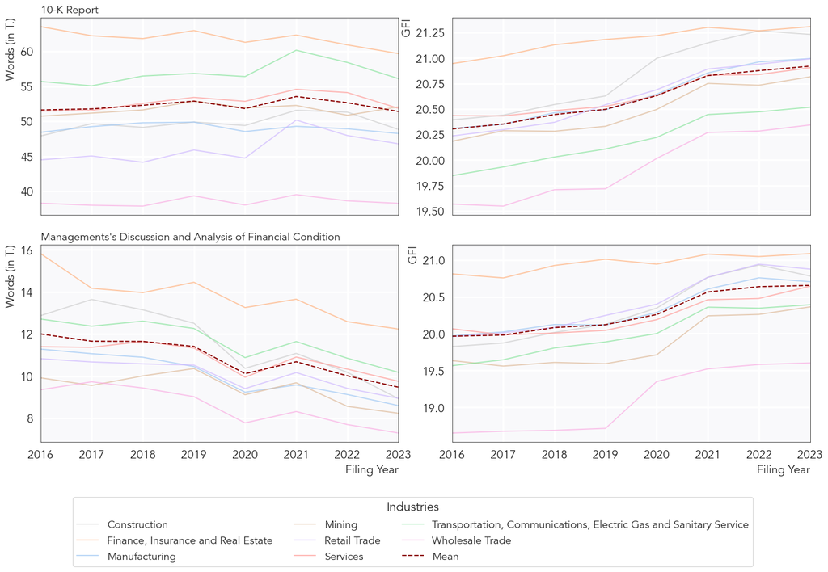

```python
# set theme
sns.set_theme(rc={
    "axes.facecolor": (236/255, 236/255, 242/255, 0.3),
    "font.family": "Avenir", # chage to times new roman to align with the paper font
    "grid.linewidth": 2.2,
    "axes.edgecolor": "black",
    "axes.linewidth": 0.5,
    "font.weight": 'normal'
})
fig, axes = plt.subplots(2, 2, figsize = (18, 10), sharex = True, constrained_layout = False)
plt.subplots_adjust(wspace = 0.15, hspace = 0.15)

############ Create the variables that will be plotted ##################

# group the dataset overall and also get its mean
df_overall_grouped = df_overall[['words', 'Industry', 'FilingYear', 'GFI']].groupby(['FilingYear', 'Industry']).mean().reset_index()
df_mean_overall = df_overall[['words', 'FilingYear', 'GFI']].groupby(['FilingYear']).mean().reset_index()
# re-scale the total number of words
df_overall_grouped['words'] = df_overall_grouped['words'] / 1_000
df_mean_overall['words'] = df_mean_overall['words'] / 1_000

# do the same for df_item7
df_item7_grouped = df_item7[['words', 'Industry', 'FilingYear', 'GFI']].groupby(['FilingYear', 'Industry']).mean().reset_index()
df_mean_item7 = df_item7[['words', 'FilingYear', 'GFI']].groupby(['FilingYear']).mean().reset_index()
# re-scale the total number of words
df_item7_grouped['words'] = df_item7_grouped['words'] / 1_000
df_mean_item7['words'] = df_mean_item7['words'] / 1_000


############ Plot the values considering the whole 10-K ##################

# now create a table with the industries in the columns and the values being the total number of words
pivot_table_overall_words = df_overall_grouped.pivot_table(index = 'FilingYear', columns = 'Industry', values = 'words')
# plot the total number of words for the whole 10-k divided by industry
pivot_table_overall_words.plot(ax = axes.flatten()[0], color = color_mapping, alpha = 0.7)
# plot the mean over all industries for the whole 10-K
df_mean_overall.plot(x = 'FilingYear', y = 'words', ax = axes.flatten()[0], color = 'darkred', linestyle = 'dashed', label = 'Mean')

# Do the same steps as above for the GFI
pivot_table_overall_gfi = df_overall_grouped.pivot_table(index = 'FilingYear', columns = 'Industry', values = 'GFI')
pivot_table_overall_gfi.plot(ax = axes.flatten()[1], color = color_mapping, alpha = 0.7)
# plot the mean
df_mean_overall.plot(x = 'FilingYear', y = 'GFI', ax = axes.flatten()[1], color = 'darkred', linestyle = 'dashed', label = 'Mean')


############## Plot the values considering only the MD&A section #############

# move the industries to be the column headers and pass their values to be the words
pivot_table_item7_words = df_item7_grouped.pivot_table(index = 'FilingYear', columns = 'Industry', values = 'words')
# plot the values
pivot_table_item7_words.plot(ax = axes.flatten()[2], color = color_mapping, alpha = 0.7)
# plot the mean
df_mean_item7.plot(x = 'FilingYear', y = 'words', ax = axes.flatten()[2], color = 'darkred', linestyle = 'dashed')
# Do the same for  the GFI at the MD&A level
pivot_table_item7_gfi = df_item7_grouped.pivot_table(index = 'FilingYear', columns = 'Industry', values = 'GFI')
pivot_table_item7_gfi.plot(ax = axes.flatten()[3], color = color_mapping, alpha = 0.7)
# plot the mean
df_mean_item7.plot(x = 'FilingYear', y = 'GFI', ax = axes.flatten()[3], color = 'darkred', linestyle = 'dashed', label = 'Mean')

# We now remove the labels (as we are using a common label to graphics) and set the x-axis limites to be between 2016 and 2023
for ax in axes.flatten():
    legend_remove = ax.get_legend()
    if legend_remove:
        legend_remove.remove()
    # Assuming ax is your Matplotlib Axes object
    ax.set_xlim(2016, 2023)
    ax.tick_params(axis = 'x', labelsize = 15)
    ax.tick_params(axis = 'y', labelsize = 15)

########## Label the axes ############
axes[0, 0].set_ylabel('Words (in T.)', loc = 'top', size = 15)
axes[1, 0].set_ylabel('Words (in T.)', loc = 'top', size = 15)
axes[0, 1].set_ylabel('GFI', loc = 'top', size =  15)
axes[1, 1].set_ylabel('GFI', loc = 'top', size = 15)
axes[1, 0].set_xlabel('Filing Year', loc = 'right', size = 15)
axes[1, 1].set_xlabel('Filing Year', loc = 'right', size = 15)

######### create the legend ###########
handles, labels = axes[0, 0].get_legend_handles_labels()
legend = fig.legend(handles, labels, loc='upper center', bbox_to_anchor=(0.5, 0.02), ncol=3, fontsize=14)
legend.set_title('Industries')
legend.get_title().set_fontsize(16)
legend.get_frame().set_facecolor((1, 1, 1, 0.7))
legend.get_title().set_fontweight('bold')

######## set title and save the picture #################
axes[0, 0].set_title('10-K Report', loc = 'left', weight = 'bold', size = 14)
axes[1, 0].set_title("Managements's Discussion and Analysis of Financial Condition", loc = 'left', weight = 'bold', size = 14)
#fig.suptitle('Evolution of Total Number of Words and GFI over Time', fontweight = 'bold', fontsize = 18)
file_name = 'Analysis_Ch1_EvolutionWordsandGFI.png'
# save the picture:
#fig.savefig(fig_dir + file_name, bbox_inches =  'tight')


title = creator.tabDesc(
    title = 'Evolution of Total Number of Words and GFI per Year',
    caption = 'Figure illustrates the evolution of text length (number of words) and GFI over the range 2016-2013 for different industriees. The top row contains statistics using the whole 10-K file, while the bottom row relates to the item 7. The dashed lines represents the mean over all industries. While the total number of words has been stable accounting for the whole 10-K and even decreasing in the case of the MD&A-sections, the Gunning Fog Index has steadly increased since 2016.',
    cap_style = 'font-size:13px; text-align: justify;',
    type = 'Fig.',
    type_num = '1.1.',
    disp = True
)
```

The picture above tells us that the average total number of words has been stable over the period of analysis when one considers the whole 10-K reports. Regarding only the MD&A-sections, the average total number of words even decreased by about 2,000 words between 2016 and 2023. This contrasts to findings in the literature, which asserts that the reports are getting lengthier. One reason for this might be that we did not condired non-alphabetic character to be words.

The GFI has steadly increased for both at a whole document (10K) and MD&A level, meaning that the language used in the files are getting more and more difficult to read.

#### Checking the Set of Complex Words (MD&A)

One of the major critics on the GFI is that it its definition of complex words are not really complex to the average investor. We will now have a closer look at the the words found to be complex in the MD&A-sections.

```python
processor = PreProcessor(
    directory = corpus_dir,
    item = 'item_7',
)

# get the raw texts in the MD&A sections of all files in the corpus
df_rawtext = processor.return_raw_item()
```

next, we create a function that will return only the complex words (words with at least 3 syllables)

```python
def create_complex_list(df, text_col = 'raw_text'):

    def count_syllables(word):
        """
        Function is used to count the syllables of a word. It is applyed to compute GF-Index
        Arguments:
            - word: the word we want to compute the number of syllabes.
        """
        dic = pyphen.Pyphen(lang='en_US')
        syllables = dic.inserted(word).count('-') + 1
        return syllables
    # iterate over the dataset
    sentences = df['raw_text'].tolist()
    complex_list = []
    for sentence in tqdm(sentences, desc = 'creating complex list'):
        tokens = [token for token in wordpunct_tokenize(sentence) if token.isalpha()]
        complex = [token for token in tokens if count_syllables(token) is not None and count_syllables(token) > 2]
        if complex:
            complex_list.append(' '.join(complex))

    return complex_list
```

```python
# keep only file names in the data set df_rawtext that are also included in the df_text_structure
df_rawtext = df_rawtext[df_rawtext['file_name'].isin(df_text_structure['filename'].tolist())]
```

```python
# apply the function above and pass the dataset as an argument
complex_list = create_complex_list(df_rawtext)
```

We now plot a word cloud with the list of complex-words:

Word Cloud: Complex Words

Fig. 1.2.: *Figure illustrates a word cloud containing the most frequent complex words found in the MD&A-sections of the 10-K files of the 394 companies in the data set.*

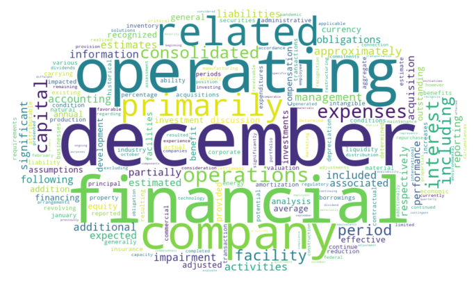

```python
# create a term-frequency matrix
tf_vectorizer = TfidfVectorizer(use_idf = False)
tf_matrix =  tf_vectorizer.fit_transform(complex_list)
feature_names = tf_vectorizer.get_feature_names_out()
# map the term frequencies to their indices (words)
tf_scores = dict(zip(feature_names, tf_matrix.sum(axis=0).A1))

cloud_mask = np.array(Image.open('01_Figures/Analysis_Ch1_MaskWC.png'))
wordcloud = WordCloud(width = 800, height = 400, background_color = 'white', mask = cloud_mask).generate_from_frequencies(tf_scores)

# display generated word cloud using matplotlib
plt.figure(figsize = (10,5))
#plt.title('Word Cloud: Complex Words', pad = 20, fontweight = 'bold', fontsize = 18)
plt.imshow(wordcloud, interpolation = 'bilinear')
plt.axis('off')
fig_name = 'Analysis_Ch1_WCComplexWords.png'
#plt.savefig(fig_dir + fig_name, bbox_inches = 'tight')
creator.tabDesc(
    title = 'Word Cloud: Complex Words',
    caption = 'Figure illustrates a word cloud containing the most frequent complex words found in the MD&A-sections of the 10-K files of the 394 companies in the data set.',
    cap_style = 'fontsize: 13px; text-align: justify;',
    type = 'Fig.',
    type_num = '1.2.',
    disp = True
)
plt.show()
```

As can be sheen in the figure above, the critic on the GFI cannot be rejected. Words like "december", "financial", "company", "performance" among others are easily understood by the average investor.

## 1.2. Distribution of Companies in the Dataset

In this section, we will take a look at the distribution of the companies found in our dataset. We will plot the number of companies by industries as well as their market value.

We load the dataset created at the end of Section 6 in the notebook `01_Scraper.ipynb` and remove those companies that were removed from the dataset in this notebook, such that only the relevant companies stays in the dataset, say, those companies that will be used in our regression analysis at a later step.

```python
# we will join the Scraper_Ch6_AggregatedFinal
df_aggregated = pd.read_csv(tables_dir + 'Scraper_Ch6_AggregatedFinal.csv', dtype = {'cik': str})
df_aggregated['cik'] = df_aggregated['cik'].str.zfill(10)
# we merge the dataset to the dataset containg the textual features of the companies
df_text_structure = pd.read_csv(tables_dir +'Analysis_Ch1_CorpusStructuralDescriptionCleaned.csv', dtype = {'cik': str})
df_text_structure['cik'] = df_text_structure['filename'].str.split('_').str.get(0)
# keep only the companied in df_aggregated that has common ciks with the df_text_structure
df_aggregated = df_aggregated[df_aggregated['cik'].isin(df_text_structure['cik'])]
```

We start by analyzing the number of companies per industry (by means of tables and charts).

```python
df_temp = df_aggregated.copy(deep = True)
# drop duplicates based on the cik column
df_temp.drop_duplicates(subset = ['cik'], inplace = True)
df_temp
df_ind_description = pd.concat([df_temp['Industry'].value_counts(),
                                df_temp['Industry'].value_counts(normalize = True).apply(lambda x: round(x, 4) * 100)], axis = 1)
df_ind_description = df_ind_description.rename_axis('Industry', axis=0)
df_ind_description.columns = ['Number of Companies', 'Percentage of Total']
creator.tabDesc(
    title = 'Companies by Industry',
    caption = 'Table shows the total number of companies in the data set divided by their industries. The first column holds the total number of companies and the second the percentage that an industry makes in relation to the whole data set. The major industry is by far Manufacturing with 155 companies (39.34%), followed by utilities (Transportation, Communications, Eletric Gas and Sanitary Service with 65 companies. Note that a better defintion for industry is the one of Sectors, as instead of using the SIC, we used the SEC-division to group the companies.',
    cap_style = 'font-size:13px; text-align: justify;',
    type = 'Tab.',
    type_num = '1.7.',
    disp = True
)
show(df_ind_description)
```

Companies by Industry

Tab. 1.7.: *Table shows the total number of companies in the data set divided by their industries. The first column holds the total number of companies and the second the percentage that an industry makes in relation to the whole data set. The major industry is by far Manufacturing with 155 companies (39.34%), followed by utilities (Transportation, Communications, Eletric Gas and Sanitary Service with 65 companies. Note that a better defintion for industry is the one of Sectors, as instead of using the SIC, we used the SEC-division to group the companies.*

| Industry | Number of Companies | Percentage of Total |
| --- | --- | --- |
| Loading... (need [help](https://mwouts.github.io/itables/troubleshooting.html)?) |  |  |

Next, we create a chart:

```python
# obtain the total number of companies per industry in a separate dataframe and sort the count in descending order
df_industries_count = df_temp.groupby(['Industry']).size().reset_index(name='count').sort_values(by = 'count', ascending = False)
# create a column to hold the colors we defined at the beginning of this notebook for each industry
df_industries_count['color'] = df_industries_count['Industry'].map(color_mapping)
```

we create a bar- and a pie chart in a single figure:

Data-Set: Tatal Number of Companies per Industry

Fig. 1.3.: *The picture illustrates the distribution of companies across industries in the Dataset. The left picture displays the total amount and the pie illustrates the percentage of an industry in relation to the total. The industry with the largest number of companies is Manufactuing with 155 companies (39.3%), followed by Utilities (Transportation, Communication...) (16.5%), services (16.2%) and the financial sector (12.4%) and retail (5.1%). The remainder makes 10.4% of the dataset. In total the data set has 394 companies distributed across 8 industries.*

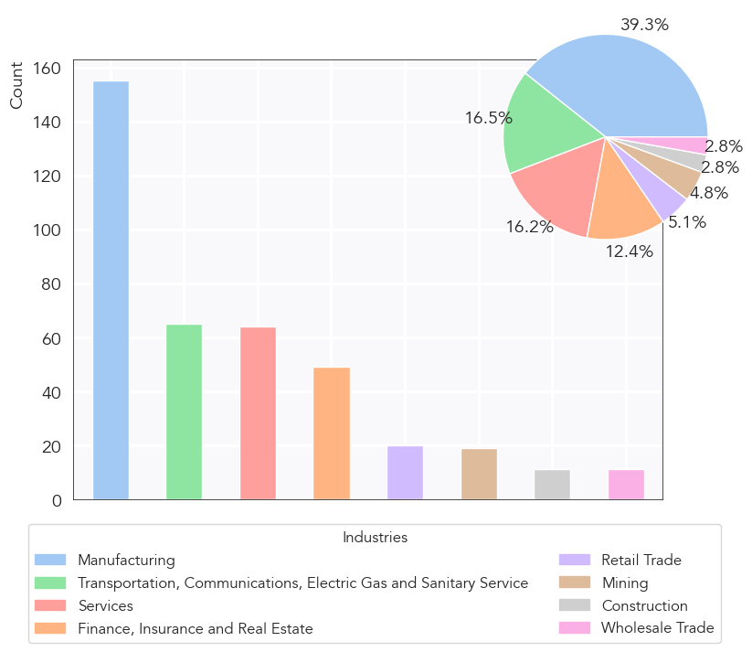

```python
# set theme
sns.set_theme(rc={
    "axes.facecolor": (236/255, 236/255, 242/255, 0.3),
    "font.family": "Avenir", # chage to times new roman to align with the paper font
    "grid.linewidth": 2.2,
    "axes.edgecolor": "black",
    "axes.linewidth": 0.5,
    "font.weight": 'normal'
})

scale = 1.3

##### specify the axis ######
fig, ax = plt.subplots(figsize = (scale * np.array([6.4, 4.8])))


##### plot the bar-chart ######
df_industries_count.plot(kind = 'bar', x = 'Industry', y = 'count', color = df_industries_count['color'].tolist(), ax = ax, label = None)
ax.set_xticklabels([])
# remove the x-label and set y-label
ax.set_ylabel('Count', loc = 'top', fontsize = 14)
ax.set_xlabel('')
ax.tick_params(labelsize = 14)
###### now add another axis to hold the pie chart ######
inset_ax = fig.add_axes([0.60, 0.52, 0.45, 0.45])
inset_ax.pie(df_industries_count['count'],
             colors = df_industries_count['color'].tolist(),
             autopct='%1.1f%%',
             startangle=0,
             pctdistance=1.15,
             textprops={'fontsize': 14})

##### Create legend patche s#####
legend_patches = [Patch(color=color, label=industry) for industry, color in zip(df_industries_count['Industry'], df_industries_count['color'])]

# Add legend below the pie chart
legend =inset_ax.legend(handles=legend_patches,
                loc='lower center',
                bbox_to_anchor=(-0.4, -1.5),
                ncol=2,
                fontsize=12,
                title = 'Industries')
legend.get_frame().set_facecolor((1, 1, 1, 0.7))
legend.get_title().set_fontweight('bold')
legend.get_title().set
#fig.suptitle('Total Number of Companies per Industry', weight = 'bold', size = 18)

# we now save the graphs to disk
#fig.savefig(fig_dir + 'Analysis_Ch1_CompaniesDist.png', bbox_inches = 'tight')
creator.tabDesc(
    title = 'Data-Set: Tatal Number of Companies per Industry',
    caption = 'The picture illustrates the distribution of companies across industries in the Dataset. The left picture displays the total amount and the pie illustrates the percentage of an industry in relation to the total. The industry with the largest number of companies is Manufactuing with 155 companies (39.3%), followed by Utilities (Transportation, Communication...) (16.5%), services (16.2%) and the financial sector (12.4%) and retail (5.1%). The remainder makes 10.4% of the dataset. In total the data set has 394 companies distributed across 8 industries.',
    cap_style = 'font-size: 13px; text-algin:justify;',
    type = 'Fig.',
    type_num = '1.3.',
    disp = True
)
```

As exemplified by the picture above, the manufacturing industry is the one with more companies in the dataset, and according to [statista](https://www.statista.com/statistics/487754/united-states-number-of-firms-industry/) website, the distribution in our dataset is not really representative of the US economy and probably cannot be generalized to the whole industry. While construction is shown to be very prevalent in the statista website, this is not the case in our dataset.